# Your Digest for Monday, Apr 08, 2024 11:59 PM

2. **Axis deviation** Left axis deviation suggests VT. (Extreme "*north-west*" axis. [Source](https://ecgwaves.com/topic/ventricular-tachycardia-vt-ecg-treatment-causes-management/)
   1. Capture beats - a normal shaped QRS complex when an SA node impulse captures the ventricles.
   2. Fusion beats: sinus and ventricular beat occur simultaneously (QRS morphology is intermediate VT beat and sinus beat)
3. Positive OR negative **concordance**
4. **AND**
5. > RSR’ complexes with a **taller “left rabbit ear”**. This is the most specific finding in favour of VT. This is in contrast to RBBB, where the right rabbit ear is taller

1. Amiodarone - more effective than lidocaine. [Source](https://www.ncbi.nlm.nih.gov/pmc/articles/PMC9181251/)
   1. Can use even in heart failure
2. Lidocaine
3. Procainamide

```
        + Olanzapine - Obesity (it can also cause weight gain)
```

> [!INFO] Easy rule to remember:  
> If a patient has had 5 doses of tetanus vaccine, with the last dose < 10 years ago, they don't require a booster vaccine nor immunoglobulins, regardless of how severe the wound is. - PassMedicine

| Apo *B48* | Chylomicrons | Signature molecule of chylomicrons |  
| Apo *B100* | VLDL, IDL and LDL | Signature molecule of endogenous lipids; *used for liver uptake of LDL* |  
| Apo *A1* | HDL | Signature molecule of HDL; recycled upon hepatic uptake of HDL particles |

- **HMG-CoA reductase:** Rate limiting enzyme in cholesterol synthesis : *found in the liver* and ? other tissues
- **LCAT** : the enzyme synthesized by the liver and attached to HDL which esterifies cholesterol so that it becomes trapped inside HDL. Required for *reverse transport* of cholesterol.
- **LPL**: lipoprotein lipase: the enzyme found on tissues which *removes lipids from VLDL* and it's derivatives, increasing their density.
> - Patients can present with elevations of a single type or mixed hyperlipidaemia.
> - The **commonest lipid disorder is familial combined hyperlipidaemia** - a mixed lipid disorder
> - Disorders causing isolated elevations in LDL and VLDL only are also somewhat common.
> - Isolated disorders of HDL are rare.
> - When evaluating hyperlipidaemia, **[[General medicine 5#Causes of secondary hyperlipidaemia|secondary causes of hyperlipidaemia]]** should be excluded

[figure not shown]

- Atleast two consecutive generations (including the index patient) are affected.

> Usually *no ketosis* like Type 1 DM.  
> Body habitus is *lean*, unlike type 2 DM and there are no features of insulin resistance.  
> | Glucokinase | HNF | IPF |  
> | ------------------------------------------------------------- | ------------------------------------------ | ----------------- |  
> | **present from birth** | teens to thirties | teens to thirties |  
> | MODY 2 | **Commonest type** (> 70%)  
> AKA (MODY-3) | |  
> | | Microvascular complications are frequent | |  
> | Mild hyperglycaemia, **Only dietary restriction is required** | Usually causes progressive hyperglycaemia | |  
> | | Can be managed well with **sulfonylureas** | |
- The **commonest subtype if HNF-1a**. (Mnemonic: looks like "Hanifah")
- They have low renal glucose threshold with **glycosuria** and **elevated HDL**. Defect is on Chromosome **12q**.
- HNF-1b (*b*) has renal involvement with **renal cysts**, proteinuria and CKD.
  - Mnemonic: HNF-1*b* - *b for balls* - i.e cysts
  - HNF types -> respond well to **sulfonylureas**.
- *Iron deficiency anaemia*
- Associated with autoimmune diseases: IBD, [[2022-November#Primary Biliary Cholangitis (aka Primary Biliary Cirrhosis)|PBC]], ILD, CLCD, epilepsy. (*Mnemonic: all acronyms*)
  - Therefore, these patients should receive pneumococcal (every 5 years) and meningococcal vaccines.
- Tissue *transglutaminase antibodies* (**IgA**) are **first line**: NICE

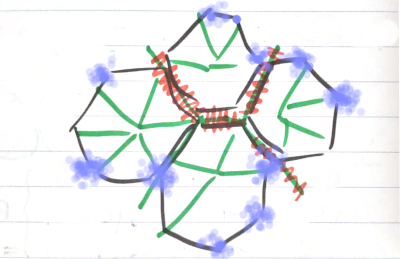

- Pathogenesis of Sjogren's: Autoimmune disease affecting **exocrine glands**.
2. **Extra glandular symptoms**
- A severely affected patient may have *florid salivary gland enlargement*, adenopathy, *antibodies to the Ro/SSA and La/SSB antigens*, *cryoglobulinemia*, **hypocomplementemia**, a propensity to develop non-Hodgkin lymphoma, and other extraglandular disease manifestations.
- 90% are positive for *Rheumatoid factor*: Kumar and Clark
- **Epidemiology**: Most Commonly occurs in *women aged 50-60 years old*.
  - Characterized by *sudden onset dry mouth* leading to difficulty in swallowing.

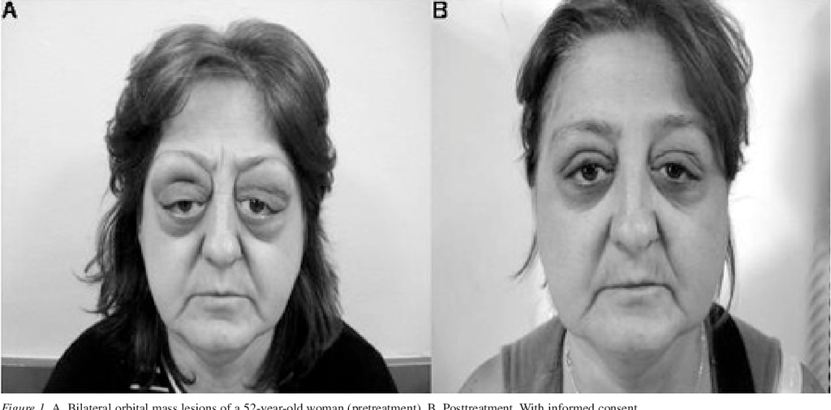

  1. **Dialysis-related amyloidosis** (DRA) is a disabling disease characterized by accumulation and tissue deposition of amyloid fibrils consisting of beta2-microglobulin (beta2-m) (**Aβ2M**) in the bone, periarticular structures, and viscera of patients with end-stage kidney disease. Beta2-m is a component of the major histocompatibility complex that is present on cell surfaces and is normally cleared by glomerular filtration
  2. Aβ2M amyloidosis presents with **carpal tunnel syndrome**.

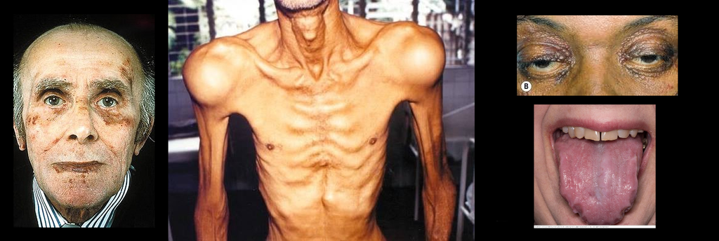

> [!INFO] SLE: *ANA is 99% sensitive* - **anti-Sm & anti-dsDNA are 99% specific** - passMedicine  
> But anti Smith and anti-dsDNA have lower sensitivities (30% and 70% respectively)

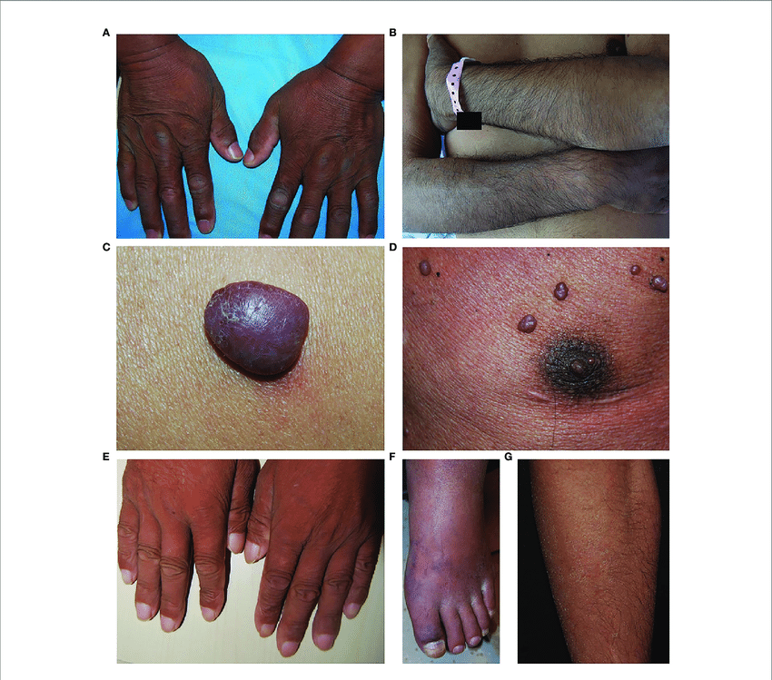

> [Source](https://www.researchgate.net/figure/Skin-changes-in-patients-with-POEMS-syndrome-A-Hyperpigmentation-B_fig1_351359584)
- Tingling in extremeties -> *peripheral neuropathy* (mnemonic: mechanics in the image -> have course hands -> they feel numb)

# Fluoroquinolones

Adverse effects

- lower **seizure threshold** in patients with epilepsy
- **tendon damage** (including rupture) - the risk is increased in patients also taking *steroids*
- *cartilage damage* has been demonstrated in animal models and for this reason quinolones are generally avoided (but not necessarily contraindicated) in children
- *lengthens QT interval*
- Avoid in pregnancy and breast feeding.
- Contraindicated in G6PD deficiency.

```
- Also of note, in post menopausal females, most of the oestrogen is produced by peripheral aromatization of androgens. [Source](https://www.researchgate.net/figure/Peripheral-aromatization-of-androgens-to-oestrogens-represents-the-principal-source-of_fig2_226077470)
    - So aromatase inhibitors like anastrozole and letrozole are used in treatment in ER+ve breast cancer.
```

Group

Cause

Mechanism

Physiologic

newborns

Puberty

Old age

Pathologic

Drugs

Cirrhosis or malnutrition

Male hypogonadism - primary or secondary

Tumors

Testicular - germ cell, Leydig cell, Sertoli cell, sex cord

Adrenal - adenoma or carcinoma

Ectopic production of human chorionic gonadotropin

Hyperthyroidism

Chronic kidney disease and dialysis

Rare causes

Enzymatic defects of testosterone production*

Androgen-insensitivity syndromes*

True hermaphroditism*

Aromatase excess syndrome

⭐

[figure not shown]

- Signs and symptoms of **strokes**.
  - Homocystaenaemia is a related condition which presents with early strokes.
- Unprovoked DVT at young age
  - There are 3 types of homocystinuria depending on the genetic defect:
    - deficiency in the cystathionine B-synthase (CBS) enzyme,
    - defective methylcobalamin synthesis,
    - or abnormality in methylene tetrahydrofolate reductase (MTHFR).
- ⭐*Cyanide-nitroprusside* test is positive. It is done on the urine to detect sulfur containing amino acids; Not sensitive or specific.
- *Blood levels for homocysteine* can be done. Samples must be transported on ice and spun **within 1 hour.**

## Comparison of homocystinuria, cystinuria and cystinosis

[Source](https://www.renalfellow.org/2008/08/03/cystinosis-versus-cystinuria/)

Homocystinuria

Cystinuria

Cystinosis

#autosomal-Recessive

#autosomal-Recessive

#autosomal-Recessive

SLC3A1 and SLC7A9

CTNS gene mutation

Deficiency in reabsorption of basic amino acids

Deficient lysosomal transporter of cystine

⬆blood homocysteine levels

Urine shows pathognomonic hexagonal crystals.

Cystine accumulates in **proximal tubule cells**

Marfanoid habitus  
Learning difficult  
Downward lens dislocation etc

**Main problem** is stone formation and complications

Fanconi Syndrome  
Hypophosphataemic rickets  
Corneal deposits

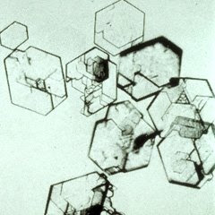

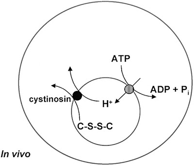

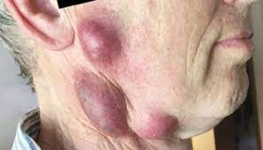

# Phenylketonuria

[Source](https://emedicine.medscape.com/article/947781-overview)

- **The most common** inborn error of amino acid metabolism.
- aka phenylalanine hydroxylase deficiency.
- There is inability to metabolise phenylalanine.
- **Intellectual impairment** is the most distinguishing feature.
- 50% have **epilepsy**.
- Extrapyramidal manifestations+
- Fair skin and fair hair due to impairment of melanin synthesis. Treatment will restore pigmentation.
- **Management**
  - Dietary: Avoid "These foods are high protein foods, such as **milk, dairy products, meat, fish, chicken, eggs, beans, and nuts**." [Source](https://depts.washington.edu/pku/about/diet.html)

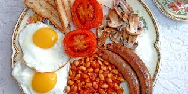

  - Medical:
    - Sapropterin - acts as a cofactor for the deficient enzyme
    - Pegvaliase - Pegylated enzyme replacement.